> **Hi, guys!** Are you interested in finance? Or Do you like the topics that related to money? Maybe, you trying to afford something that you need but cannot find the person to ask for help! Or You just wondering how to raise your money but don't you know what to do? Ok, today we have done a little job that might be helpful for you! So, We have found a dataset related to Prosper peer-to-peer lending platform. Are you heard about it? If no, that's ok! I also hadn't heard about it before starting the final project of Udacity Data Analyst Nanodegree. There you can get a loan or invest for borrowers. And It is very interesting online experience. So, let's dive in to the interesting facts about the dataset!

# A Quick Overview to Prosper Loan Data

**So, guys!** I'm not good at finance. And I know the numbers sometimes can be really confusing at all. But if you find the right way for dealing with them, they can tell you a story! And happenings in today's story is all up to you! Because you give questions to the numbers and they tell you the answers. So, be careful about asking the questions. Right questions leads to an interesting story. Now, let's start our investigations towards our story!

But, first we must look through the dataset to identify its structure. So, let's fetch the data to our workspace!

```python
# you can see the general information about the data from the table above, but what about looking through data
# more deeper. pandas set_option can help us in this place
pd.set_option('display.max_columns', len(df.columns))
df
```

[output not shown]

[output not shown]

|  | ListingKey | ListingNumber | ListingCreationDate | CreditGrade | Term | LoanStatus | ClosedDate | BorrowerAPR | BorrowerRate | LenderYield | EstimatedEffectiveYield | EstimatedLoss | EstimatedReturn | ProsperRating (numeric) | ProsperRating (Alpha) | ProsperScore | ListingCategory (numeric) | BorrowerState | Occupation | EmploymentStatus | EmploymentStatusDuration | IsBorrowerHomeowner | CurrentlyInGroup | GroupKey | DateCreditPulled | CreditScoreRangeLower | CreditScoreRangeUpper | FirstRecordedCreditLine | CurrentCreditLines | … |
| --- | --- | --- | --- | --- | --- | --- | --- | --- | --- | --- | --- | --- | --- | --- | --- | --- | --- | --- | --- | --- | --- | --- | --- | --- | --- | --- | --- | --- | --- | --- |
| 0 | 1021339766868145413AB3B | 193129 | 2007-08-26 19:09:29.263000000 | C | 36 | Completed | 2009-08-14 00:00:00 | 0.16516 | 0.1580 | 0.1380 | NaN | NaN | NaN | NaN | NaN | NaN | 0 | CO | Other | Self-employed | 2.0 | True | True | NaN | 2007-08-26 18:41:46.780000000 | 640.0 | 659.0 | 2001-10-11 00:00:00 | 5.0 | … |
| 1 | 10273602499503308B223C1 | 1209647 | 2014-02-27 08:28:07.900000000 | NaN | 36 | Current | NaN | 0.12016 | 0.0920 | 0.0820 | 0.07960 | 0.0249 | 0.05470 | 6.0 | A | 7.0 | 2 | CO | Professional | Employed | 44.0 | False | False | NaN | 2014-02-27 08:28:14 | 680.0 | 699.0 | 1996-03-18 00:00:00 | 14.0 | … |
| 2 | 0EE9337825851032864889A | 81716 | 2007-01-05 15:00:47.090000000 | HR | 36 | Completed | 2009-12-17 00:00:00 | 0.28269 | 0.2750 | 0.2400 | NaN | NaN | NaN | NaN | NaN | NaN | 0 | GA | Other | Not available | NaN | False | True | 783C3371218786870A73D20 | 2007-01-02 14:09:10.060000000 | 480.0 | 499.0 | 2002-07-27 00:00:00 | NaN | … |
| 3 | 0EF5356002482715299901A | 658116 | 2012-10-22 11:02:35.010000000 | NaN | 36 | Current | NaN | 0.12528 | 0.0974 | 0.0874 | 0.08490 | 0.0249 | 0.06000 | 6.0 | A | 9.0 | 16 | GA | Skilled Labor | Employed | 113.0 | True | False | NaN | 2012-10-22 11:02:32 | 800.0 | 819.0 | 1983-02-28 00:00:00 | 5.0 | … |
| 4 | 0F023589499656230C5E3E2 | 909464 | 2013-09-14 18:38:39.097000000 | NaN | 36 | Current | NaN | 0.24614 | 0.2085 | 0.1985 | 0.18316 | 0.0925 | 0.09066 | 3.0 | D | 4.0 | 2 | MN | Executive | Employed | 44.0 | True | False | NaN | 2013-09-14 18:38:44 | 680.0 | 699.0 | 2004-02-20 00:00:00 | 19.0 | … |
| 5 | 0F05359734824199381F61D | 1074836 | 2013-12-14 08:26:37.093000000 | NaN | 60 | Current | NaN | 0.15425 | 0.1314 | 0.1214 | 0.11567 | 0.0449 | 0.07077 | 5.0 | B | 10.0 | 1 | NM | Professional | Employed | 82.0 | True | False | NaN | 2013-12-14 08:26:40 | 740.0 | 759.0 | 1973-03-01 00:00:00 | 21.0 | … |
| 6 | 0F0A3576754255009D63151 | 750899 | 2013-04-12 09:52:56.147000000 | NaN | 36 | Current | NaN | 0.31032 | 0.2712 | 0.2612 | 0.23820 | 0.1275 | 0.11070 | 2.0 | E | 2.0 | 1 | KS | Sales - Retail | Employed | 172.0 | False | False | NaN | 2013-04-12 09:52:53 | 680.0 | 699.0 | 2000-09-29 00:00:00 | 10.0 | … |
| 7 | 0F1035772717087366F9EA7 | 768193 | 2013-05-05 06:49:27.493000000 | NaN | 36 | Current | NaN | 0.23939 | 0.2019 | 0.1919 | 0.17830 | 0.0799 | 0.09840 | 4.0 | C | 4.0 | 2 | CA | Laborer | Employed | 103.0 | False | False | NaN | 2013-05-05 06:49:25 | 700.0 | 719.0 | 1999-02-25 00:00:00 | 6.0 | … |
| 8 | 0F043596202561788EA13D5 | 1023355 | 2013-12-02 10:43:39.117000000 | NaN | 36 | Current | NaN | 0.07620 | 0.0629 | 0.0529 | 0.05221 | 0.0099 | 0.04231 | 7.0 | AA | 9.0 | 7 | IL | Food Service | Employed | 269.0 | True | False | NaN | 2013-12-02 10:43:39 | 820.0 | 839.0 | 1993-04-01 00:00:00 | 17.0 | … |
| 9 | 0F043596202561788EA13D5 | 1023355 | 2013-12-02 10:43:39.117000000 | NaN | 36 | Current | NaN | 0.07620 | 0.0629 | 0.0529 | 0.05221 | 0.0099 | 0.04231 | 7.0 | AA | 11.0 | 7 | IL | Food Service | Employed | 269.0 | True | False | NaN | 2013-12-02 10:43:39 | 820.0 | 839.0 | 1993-04-01 00:00:00 | 17.0 | … |
| 10 | 0F123545674891886D9F106 | 587746 | 2012-05-10 07:04:01.577000000 | NaN | 60 | Current | NaN | 0.27462 | 0.2489 | 0.2389 | 0.23320 | 0.0890 | 0.14420 | 4.0 | C | 7.0 | 1 | MD | Fireman | Employed | 300.0 | False | False | NaN | 2012-04-22 08:38:09 | 640.0 | 659.0 | 1989-11-29 00:00:00 | 2.0 | … |
| 11 | 0F1734025150298088A5F2B | 213551 | 2007-10-09 20:28:33.640000000 | C | 36 | Completed | 2008-01-07 00:00:00 | 0.15033 | 0.1325 | 0.1225 | NaN | NaN | NaN | NaN | NaN | NaN | 0 | NaN | Waiter/Waitress | Full-time | 19.0 | False | False | NaN | 2007-10-08 13:13:44.363000000 | 640.0 | 659.0 | 2000-11-13 00:00:00 | 2.0 | … |
| 12 | 0F1A3597143888805163EF7 | 1081604 | 2013-12-15 20:01:10.757000000 | NaN | 36 | Past Due (1-15 days) | NaN | 0.17969 | 0.1435 | 0.1335 | 0.12640 | 0.0524 | 0.07400 | 5.0 | B | 4.0 | 1 | AL | Sales - Retail | Employed | 1.0 | False | False | NaN | 2013-12-15 20:01:13 | 680.0 | 699.0 | 1996-11-09 00:00:00 | 9.0 | … |
| 13 | 0F1C3583260311305D68F87 | 840820 | 2013-07-15 16:28:28.087000000 | NaN | 36 | Current | NaN | 0.13138 | 0.1034 | 0.0934 | 0.09050 | 0.0274 | 0.06310 | 6.0 | A | 8.0 | 1 | AZ | Construction | Employed | 98.0 | True | False | NaN | 2013-07-11 16:51:03 | 740.0 | 759.0 | 2007-03-20 00:00:00 | 9.0 | … |
| 14 | 0F353575943675863D1AFC0 | 757359 | 2013-04-19 11:17:41.700000000 | NaN | 60 | Current | NaN | 0.11695 | 0.0949 | 0.0849 | 0.08270 | 0.0224 | 0.06030 | 6.0 | A | 8.0 | 1 | VA | Computer Programmer | Employed | 35.0 | False | False | NaN | 2013-04-19 11:17:38 | 740.0 | 759.0 | 1992-07-06 00:00:00 | 25.0 | … |
| 15 | 0F483544120452347F48121 | 577164 | 2012-04-10 09:14:46.297000000 | NaN | 36 | Defaulted | 2012-12-19 00:00:00 | 0.35797 | 0.3177 | 0.3077 | 0.28960 | 0.1650 | 0.12460 | 1.0 | HR | 5.0 | 13 | FL | Other | Other | 121.0 | True | False | NaN | 2012-04-10 09:14:41 | 700.0 | 719.0 | 1999-03-08 00:00:00 | 10.0 | … |
| 16 | 0F4835843081468212F0892 | 841846 | 2013-07-16 12:42:48.680000000 | NaN | 60 | Current | NaN | 0.30748 | 0.2809 | 0.2709 | 0.24730 | 0.1225 | 0.12480 | 2.0 | E | 4.0 | 6 | CA | Professional | Full-time | 133.0 | True | False | NaN | 2013-07-16 12:42:39 | 640.0 | 659.0 | 2001-08-11 00:00:00 | 6.0 | … |
| 17 | 0FDF336575182398852A8DC | 31540 | 2006-08-15 12:21:09.433000000 | AA | 36 | Chargedoff | 2008-05-22 00:00:00 | 0.13202 | 0.1250 | 0.1175 | NaN | NaN | NaN | NaN | NaN | NaN | 0 | NaN | Professional | Not available | NaN | True | True | EF543365873906104DC9A04 | 2006-08-15 10:56:13.020000000 | 760.0 | 779.0 | 1990-05-19 00:00:00 | NaN | … |
| 18 | 0FF2357105361877390B58D | 716058 | 2013-02-20 03:48:37.470000000 | NaN | 36 | Current | NaN | 0.12528 | 0.0974 | 0.0874 | 0.08490 | 0.0249 | 0.06000 | 6.0 | A | 7.0 | 1 | PA | Sales - Commission | Employed | 179.0 | False | False | NaN | 2013-02-20 03:48:33 | 740.0 | 759.0 | 1994-12-20 00:00:00 | 10.0 | … |
| 19 | 0FFC35866018516621B0D3F | 875565 | 2013-08-21 06:49:02.093000000 | NaN | 60 | Current | NaN | 0.24754 | 0.2225 | 0.2125 | 0.19520 | 0.1025 | 0.09270 | 3.0 | D | 8.0 | 1 | OR | Laborer | Employed | 18.0 | False | False | NaN | 2013-10-04 17:49:53 | 680.0 | 699.0 | 2007-08-13 00:00:00 | 15.0 | … |
| 20 | 101635959323992333B3C70 | 1011916 | 2013-11-22 11:35:02.987000000 | NaN | 36 | Current | NaN | 0.16732 | 0.1314 | 0.1214 | 0.11567 | 0.0449 | 0.07077 | 5.0 | B | 7.0 | 1 | MN | Retail Management | Employed | 175.0 | True | False | NaN | 2013-11-22 11:35:09 | 660.0 | 679.0 | 1984-12-06 00:00:00 | 9.0 | … |
| 21 | 1017340630713945364DA6B | 241498 | 2007-11-30 20:33:49.227000000 | D | 36 | Completed | 2010-12-12 00:00:00 | 0.21488 | 0.2075 | 0.1975 | NaN | NaN | NaN | NaN | NaN | NaN | 0 | MI | Professional | Full-time | 36.0 | False | True | 6C2E3384236387493493CB6 | 2007-11-11 14:24:41.350000000 | 620.0 | 639.0 | 2003-06-20 00:00:00 | 4.0 | … |
| 22 | 101735700321773921526BF | 706927 | 2013-01-30 09:36:13.783000000 | NaN | 36 | Current | NaN | 0.35356 | 0.3134 | 0.3034 | 0.27600 | 0.1575 | 0.11850 | 1.0 | HR | 2.0 | 1 | NY | Other | Other | 68.0 | False | False | NaN | 2013-01-30 09:36:09 | 700.0 | 719.0 | 1988-03-01 00:00:00 | 9.0 | … |
| 23 | 101B35764008108187B2EBA | 758964 | 2013-04-22 13:29:19.073000000 | NaN | 36 | Defaulted | 2013-12-26 00:00:00 | 0.28032 | 0.2419 | 0.2319 | 0.21260 | 0.1075 | 0.10510 | 3.0 | D | 5.0 | 15 | IL | Skilled Labor | Employed | 3.0 | False | False | NaN | 2013-04-22 13:29:14 | 680.0 | 699.0 | 1998-06-09 00:00:00 | 7.0 | … |
| 24 | 101B3596709094692AC79C0 | 1046345 | 2013-12-03 11:34:46.127000000 | NaN | 36 | Current | NaN | 0.19859 | 0.1620 | 0.1520 | 0.14256 | 0.0649 | 0.07766 | 4.0 | C | 5.0 | 1 | LA | Other | Employed | 91.0 | True | False | NaN | 2013-12-03 11:34:55 | 660.0 | 679.0 | 1994-05-03 00:00:00 | 10.0 | … |
| 25 | 10223590888942486E3826E | 950067 | 2013-10-02 14:31:09.157000000 | NaN | 36 | Current | NaN | 0.30182 | 0.2629 | 0.2529 | 0.23057 | 0.1275 | 0.10307 | 2.0 | E | 3.0 | 15 | CA | Engineer - Mechanical | Employed | 15.0 | False | False | NaN | 2013-09-21 15:33:38 | 680.0 | 699.0 | 2000-05-11 00:00:00 | 2.0 | … |
| 26 | 0F4F3571508214190FD75CB | 713131 | 2013-02-12 18:07:31.690000000 | NaN | 60 | Completed | 2013-10-22 00:00:00 | 0.30748 | 0.2809 | 0.2709 | 0.24730 | 0.1225 | 0.12480 | 2.0 | E | 3.0 | 1 | NY | Sales - Commission | Employed | 25.0 | False | False | NaN | 2013-02-12 18:07:23 | 660.0 | 679.0 | 1975-10-26 00:00:00 | 7.0 | … |
| 27 | 0F5034867864161084F3789 | 463083 | 2010-06-16 16:23:44.533000000 | NaN | 36 | Completed | 2013-07-03 00:00:00 | 0.11296 | 0.0920 | 0.0820 | 0.06080 | 0.0210 | 0.06080 | 6.0 | A | 9.0 | 1 | CO | Executive | Full-time | 10.0 | True | False | NaN | 2010-06-04 10:18:55 | 700.0 | 719.0 | 2000-04-11 00:00:00 | 16.0 | … |
| 28 | 0F53359346357513247D86B | 989519 | 2013-11-02 16:01:28.050000000 | NaN | 36 | Current | NaN | 0.20268 | 0.1660 | 0.1560 | 0.14661 | 0.0624 | 0.08421 | 4.0 | C | 4.0 | 2 | PA | Military Enlisted | Employed | 48.0 | True | False | NaN | 2013-11-02 16:01:30 | 720.0 | 739.0 | 2009-12-22 00:00:00 | 5.0 | … |
| 29 | 0F563597161095613517437 | 1051243 | 2013-12-17 09:18:33.220000000 | NaN | 36 | Current | NaN | 0.15223 | 0.1239 | 0.1139 | 0.10900 | 0.0399 | 0.06910 | 6.0 | A | 6.0 | 1 | LA | Other | Employed | 16.0 | True | False | NaN | 2013-12-17 09:18:36 | 740.0 | 759.0 | 1973-12-01 00:00:00 | 24.0 | … |
| ... | ... | ... | ... | ... | ... | ... | ... | ... | ... | ... | ... | ... | ... | ... | ... | ... | ... | ... | ... | ... | ... | ... | ... | ... | ... | ... | ... | ... | ... | … |
| 113907 | C982359388882926442DE72 | 1005215 | 2013-11-09 06:55:05.690000000 | NaN | 36 | Current | NaN | 0.35356 | 0.3134 | 0.3034 | 0.27598 | 0.1625 | 0.11348 | 1.0 | HR | 2.0 | 1 | AZ | Sales - Retail | Employed | 86.0 | False | False | NaN | 2013-11-09 06:55:07 | 640.0 | 659.0 | 1998-09-30 00:00:00 | 15.0 | … |
| 113908 | C9843500054876019D611A1 | 486057 | 2010-11-29 10:40:09.730000000 | NaN | 36 | Completed | 2011-01-31 00:00:00 | 0.35858 | 0.3220 | 0.3120 | 0.15570 | 0.1420 | 0.15570 | 2.0 | E | 5.0 | 3 | NY | Sales - Commission | Employed | 68.0 | False | False | NaN | 2010-11-22 20:51:48 | 700.0 | 719.0 | 2005-09-26 00:00:00 | 17.0 | … |
| 113909 | C98635564651525938EB38E | 635880 | 2012-09-08 10:34:38.837000000 | NaN | 60 | Current | NaN | 0.27554 | 0.2498 | 0.2398 | 0.23410 | 0.0849 | 0.14920 | 4.0 | C | 7.0 | 2 | FL | Clerical | Employed | 265.0 | True | False | NaN | 2012-09-08 10:34:37 | 800.0 | 819.0 | 1986-08-01 00:00:00 | 6.0 | … |
| 113910 | C9873600264828351437CAB | 1161059 | 2014-01-24 19:56:49.960000000 | NaN | 36 | Current | NaN | 0.32446 | 0.2850 | 0.2750 | 0.25006 | 0.1475 | 0.10256 | 2.0 | E | 2.0 | 1 | TX | Executive | Employed | 8.0 | False | False | NaN | 2014-01-22 10:53:45 | 640.0 | 659.0 | 1985-08-01 00:00:00 | 9.0 | … |
| 113911 | C9883594035073098BC5D51 | 996496 | 2013-11-15 11:42:47.540000000 | NaN | 36 | Current | NaN | 0.25330 | 0.2155 | 0.2055 | 0.18917 | 0.0975 | 0.09167 | 3.0 | D | 3.0 | 14 | MD | Other | Employed | 51.0 | False | False | NaN | 2013-11-15 11:42:47 | 660.0 | 679.0 | 1998-04-28 00:00:00 | 7.0 | … |
| 113912 | C98A3597264633447D66DF9 | 1083677 | 2013-12-16 16:36:00.990000000 | NaN | 36 | Current | NaN | 0.06726 | 0.0605 | 0.0505 | 0.05000 | 0.0074 | 0.04260 | 7.0 | AA | 11.0 | 2 | MN | Scientist | Employed | 102.0 | False | True | NaN | 2013-12-16 16:36:03 | 800.0 | 819.0 | 1999-04-23 00:00:00 | 10.0 | … |
| 113913 | D2013482695428940FAD9E3 | 455673 | 2010-04-25 15:13:27.963000000 | NaN | 36 | Completed | 2013-05-05 00:00:00 | 0.12410 | 0.1030 | 0.0930 | 0.07170 | 0.0210 | 0.07170 | 6.0 | A | 9.0 | 1 | WA | Analyst | Full-time | 19.0 | True | False | NaN | 2010-04-25 15:02:40 | 780.0 | 799.0 | 1993-02-03 00:00:00 | 19.0 | … |
| 113914 | D20533652658825353F6597 | 30223 | 2006-08-09 14:34:40.010000000 | HR | 36 | Defaulted | 2007-03-19 00:00:00 | 0.25757 | 0.2500 | 0.2450 | NaN | NaN | NaN | NaN | NaN | NaN | 0 | CA | NaN | NaN | NaN | False | True | 3D4D3366260257624AB272D | 2006-08-09 14:32:18.527000000 | 520.0 | 539.0 | 1998-10-23 00:00:00 | NaN | … |
| 113915 | D2053427325575423785798 | 374730 | 2008-07-29 05:22:29.390000000 | D | 36 | Completed | 2011-09-28 00:00:00 | 0.22237 | 0.2000 | 0.1900 | NaN | NaN | NaN | NaN | NaN | NaN | 7 | MA | Other | Full-time | 43.0 | True | True | 41F83374830943275CE6888 | 2008-07-23 07:48:01.427000000 | 620.0 | 639.0 | 2001-01-31 00:00:00 | 13.0 | … |
| 113916 | D2063562664602024E13D82 | 667047 | 2012-11-08 20:07:36.600000000 | NaN | 36 | Current | NaN | 0.33286 | 0.2932 | 0.2832 | 0.25750 | 0.1425 | 0.11500 | 2.0 | E | 6.0 | 13 | FL | Professional | Employed | 149.0 | False | False | NaN | 2012-10-27 21:31:23 | 660.0 | 679.0 | 1987-12-01 00:00:00 | 5.0 | … |
| 113917 | D2063594229009539839457 | 1028126 | 2013-11-23 04:52:50.057000000 | NaN | 36 | Current | NaN | 0.32446 | 0.2850 | 0.2750 | 0.25006 | 0.1475 | 0.10256 | 2.0 | E | 2.0 | 1 | OH | Clerical | Employed | 32.0 | False | False | NaN | 2013-11-23 04:52:52 | 660.0 | 679.0 | 1984-07-02 00:00:00 | 8.0 | … |
| 113918 | D207342464194217591D1E1 | 353488 | 2008-06-19 12:02:53.300000000 | A | 36 | Defaulted | 2011-01-27 00:00:00 | 0.12201 | 0.1080 | 0.0980 | NaN | NaN | NaN | NaN | NaN | NaN | 4 | CA | Social Worker | Full-time | 252.0 | True | False | NaN | 2008-06-19 10:02:10.457000000 | 740.0 | 759.0 | 1983-11-01 00:00:00 | 23.0 | … |
| 113919 | D20C3577637248543A1F80C | 772509 | 2013-05-07 18:49:59.750000000 | NaN | 36 | Current | NaN | 0.27285 | 0.2346 | 0.2246 | 0.20640 | 0.1025 | 0.10390 | 3.0 | D | 3.0 | 2 | IL | Other | Other | 12.0 | True | False | NaN | 2013-05-07 18:49:57 | 680.0 | 699.0 | 1996-12-18 00:00:00 | 8.0 | … |
| 113920 | D20E358076984586576526D | 804763 | 2013-06-11 05:49:40.247000000 | NaN | 36 | Current | NaN | 0.35356 | 0.3134 | 0.3034 | 0.27600 | 0.1575 | 0.11850 | 1.0 | HR | 2.0 | 1 | NJ | Retail Management | Employed | 110.0 | True | False | NaN | 2013-06-11 05:49:29 | 740.0 | 759.0 | 1998-10-12 00:00:00 | 15.0 | … |
| 113921 | D21A33647075665665BE266 | 4 | 2005-11-09 20:44:28.847000000 | AA | 36 | Completed | 2005-11-25 00:00:00 | NaN | 0.0400 | 0.0350 | NaN | NaN | NaN | NaN | NaN | NaN | 0 | NaN | NaN | NaN | NaN | False | False | B8143364846229046768A83 | 2005-11-09 20:44:28.847000000 | NaN | NaN | NaN | NaN | … |
| 113922 | D2293427338962159DA5143 | 379986 | 2008-08-08 16:58:54.760000000 | C | 36 | Completed | 2011-08-19 00:00:00 | 0.15094 | 0.1295 | 0.1195 | NaN | NaN | NaN | NaN | NaN | NaN | 5 | GA | Other | Full-time | 115.0 | True | False | NaN | 2008-08-08 16:44:27.820000000 | 640.0 | 659.0 | 1999-06-23 00:00:00 | 8.0 | … |
| 113923 | E334343080922352965DF86 | 395877 | 2008-09-10 08:26:30.537000000 | B | 36 | Completed | 2011-09-23 00:00:00 | 0.22378 | 0.2089 | 0.1989 | NaN | NaN | NaN | NaN | NaN | NaN | 1 | MS | Clergy | Full-time | 83.0 | True | False | NaN | 2008-09-10 08:24:33.180000000 | 700.0 | 719.0 | 1997-03-19 00:00:00 | 15.0 | … |
| 113924 | E340356181565702714DBCE | 657862 | 2012-10-20 19:15:52.670000000 | NaN | 60 | Current | NaN | 0.17317 | 0.1499 | 0.1399 | 0.13460 | 0.0349 | 0.09970 | 6.0 | A | 8.0 | 13 | WA | Other | Employed | 56.0 | False | False | NaN | 2012-10-20 19:15:50 | 640.0 | 659.0 | 2002-11-15 00:00:00 | 6.0 | … |
| 113925 | E3423576946812123E4798D | 760946 | 2013-04-25 13:54:45.017000000 | NaN | 36 | Current | NaN | 0.31032 | 0.2712 | 0.2612 | 0.23820 | 0.1275 | 0.11070 | 2.0 | E | 2.0 | 1 | NY | Homemaker | Employed | 31.0 | False | False | NaN | 2013-04-25 06:58:37 | 680.0 | 699.0 | 1999-02-16 00:00:00 | 7.0 | … |
| 113926 | E34333654295683286C35C2 | 28121 | 2006-08-01 10:31:31.143000000 | E | 36 | Defaulted | 2007-09-06 00:00:00 | 0.29776 | 0.2900 | 0.2850 | NaN | NaN | NaN | NaN | NaN | NaN | 0 | CA | Other | Not available | NaN | False | False | NaN | 2006-08-01 10:10:42.370000000 | 540.0 | 559.0 | 1996-03-26 00:00:00 | NaN | … |
| 113927 | E3433419834735803891976 | 322787 | 2008-04-30 21:25:19.670000000 | AA | 36 | Completed | 2011-05-09 00:00:00 | 0.07469 | 0.0679 | 0.0579 | NaN | NaN | NaN | NaN | NaN | NaN | 4 | WA | Executive | Full-time | 69.0 | True | True | D1413413671123312FAD936 | 2008-04-30 21:20:54.587000000 | 760.0 | 779.0 | 1972-09-09 00:00:00 | 10.0 | … |
| 113928 | E34935176664905343E01EA | 510097 | 2011-06-06 19:02:44.443000000 | NaN | 36 | Completed | 2011-09-19 00:00:00 | 0.22362 | 0.1899 | 0.1799 | 0.17570 | 0.0610 | 0.11470 | 4.0 | C | 6.0 | 3 | CO | Other | Full-time | 22.0 | False | False | NaN | 2011-06-03 16:06:00 | 740.0 | 759.0 | 2004-06-06 00:00:00 | 4.0 | … |
| 113929 | E3553583161337791FCB87F | 830413 | 2013-07-06 17:40:01.657000000 | NaN | 36 | Completed | 2014-02-07 00:00:00 | 0.30285 | 0.2639 | 0.2539 | 0.23180 | 0.1225 | 0.10930 | 2.0 | E | 3.0 | 2 | FL | Accountant/CPA | Employed | 25.0 | False | False | NaN | 2013-07-06 17:39:52 | 660.0 | 679.0 | 2008-11-17 00:00:00 | 7.0 | … |
| 113930 | E35D3584034795373BCD69A | 831523 | 2013-07-08 10:24:49.700000000 | NaN | 36 | Current | NaN | 0.20053 | 0.1639 | 0.1539 | 0.14520 | 0.0574 | 0.08780 | 5.0 | B | 6.0 | 1 | IN | Professional | Employed | 85.0 | True | False | NaN | 2013-07-08 10:24:38 | 680.0 | 699.0 | 1999-12-20 00:00:00 | 16.0 | … |
| 113931 | E36F36005339663245C20F8 | 1141292 | 2014-01-16 20:13:08.040000000 | NaN | 60 | Current | NaN | 0.15016 | 0.1274 | 0.1174 | 0.11210 | 0.0424 | 0.06970 | 5.0 | B | 6.0 | 3 | IL | Analyst | Employed | 12.0 | False | False | NaN | 2014-01-03 10:17:23 | 800.0 | 819.0 | 1975-05-01 00:00:00 | 13.0 | … |
| 113932 | E6D9357655724827169606C | 753087 | 2013-04-14 05:55:02.663000000 | NaN | 36 | Current | NaN | 0.22354 | 0.1864 | 0.1764 | 0.16490 | 0.0699 | 0.09500 | 4.0 | C | 5.0 | 1 | IL | Food Service Management | Employed | 246.0 | True | False | NaN | 2013-04-14 05:54:58 | 700.0 | 719.0 | 1997-09-01 00:00:00 | 9.0 | … |
| 113933 | E6DB353036033497292EE43 | 537216 | 2011-11-03 20:42:55.333000000 | NaN | 36 | FinalPaymentInProgress | NaN | 0.13220 | 0.1110 | 0.1010 | 0.10070 | 0.0200 | 0.08070 | 6.0 | A | 8.0 | 7 | PA | Professional | Employed | 21.0 | True | False | NaN | 2011-11-03 20:42:53 | 700.0 | 719.0 | 1992-01-17 00:00:00 | 14.0 | … |
| 113934 | E6E13596170052029692BB1 | 1069178 | 2013-12-13 05:49:12.703000000 | NaN | 60 | Current | NaN | 0.23984 | 0.2150 | 0.2050 | 0.18828 | 0.1025 | 0.08578 | 3.0 | D | 3.0 | 1 | TX | Other | Employed | 84.0 | True | False | NaN | 2013-12-13 05:49:15 | 700.0 | 719.0 | 2002-02-25 00:00:00 | 12.0 | … |
| 113935 | E6EB3531504622671970D9E | 539056 | 2011-11-14 13:18:26.597000000 | NaN | 60 | Completed | 2013-08-13 00:00:00 | 0.28408 | 0.2605 | 0.2505 | 0.24450 | 0.0850 | 0.15950 | 4.0 | C | 5.0 | 2 | GA | Food Service | Full-time | 94.0 | True | False | NaN | 2011-11-14 13:18:24 | 680.0 | 699.0 | 1993-12-01 00:00:00 | 11.0 | … |
| 113936 | E6ED3600409833199F711B7 | 1140093 | 2014-01-15 09:27:37.657000000 | NaN | 36 | Current | NaN | 0.13189 | 0.1039 | 0.0939 | 0.09071 | 0.0299 | 0.06081 | 6.0 | A | 7.0 | 1 | NY | Professor | Employed | 244.0 | False | False | NaN | 2014-01-15 09:27:40 | 680.0 | 699.0 | 1995-01-01 00:00:00 | 10.0 | … |

113937 rows × 81 columns

## Looking through the dataframe maybe you wondering, Oh no, There is a lot information and I don't know what to investigate!

> **Don't worry! I was also in that manner.** But soon I decided to start with the first thing that came to my mind! And it worked well. So, let's find answer to our first question!

**How much loan do people get most often?** We can find the answer using **LoanOriginalAmount** column.

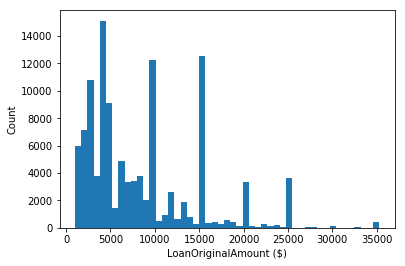

```python
# to answer the question, we use matplotlib's hist function
bin_list = np.arange(1000, df['LoanOriginalAmount'].max() + 700, 700)
plt.hist(df['LoanOriginalAmount'], bins = bin_list);
plt.xlabel('LoanOriginalAmount ($)')
plt.ylabel('Count')
```

The histogram illustrates that most often people tend to get a loan around 5k, 10k, or 15k dollars. The people who get a loan more than 15k not that much. But lower loans are most often.

**From the table above you can see a colum named "Investors". I interested in how much money per investor invests in general.**

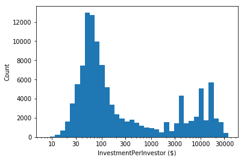

```python
# to do this we need to create a new column for investment per investor
df['investment_per_investor'] = df['LoanOriginalAmount']/df['Investors']

bin_list = 10 ** np.arange(0.86, np.log10(df['investment_per_investor'].max()) + 0.1, 0.1)
x_ticks = [10, 30, 100, 300, 1000, 3000, 10000, 30000]
x_labels = ['{}'.format(val) for val in x_ticks]

plt.hist(df['investment_per_investor'], bins = bin_list);
plt.xscale('log')
plt.xticks(x_ticks, x_labels);
plt.xlabel('InvestmentPerInvestor ($)')
plt.ylabel('Count')
```

Yeah! you can see the most popular investment between 30 and 100 dollars. But there is also big investors that can invest dozens of thousand dollars.

> **The most interesting thing I liked about the dataframe, it has got a lot of columns!** And you can take any of them as center of interest! And now I have interested in CreditGrade and ProsperScore columns.

CreditGrade column has grading for loans before 2009

- AA, A, B are good grades
- C, D are moderate grades
- E, HR or NC are low grades

ProsperScore column has grading for loans after 2009

- grading includes numbers from 1 to 11, they mean low to high grades respectively

**So, let's see which grades for loans are most often!**

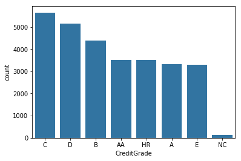

```python
order_credit = df['CreditGrade'].value_counts().index
base_color = sns.color_palette()[0]
sns.countplot(data = df, x = 'CreditGrade', color = base_color, order = order_credit);
```

You can see there moderate grades for loans are most often. **What about looking through the proportions of the gradedings.**

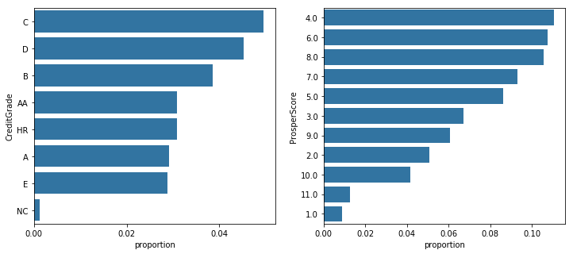

```python
# now we are ready to plot
plt.figure(figsize = (12, 5))

# let's plot proportions for two gradings at once
col_list = ['CreditGrade', 'ProsperScore']
data = df

for i in range(len(col_list)):

    plt.subplot(1, 2, i + 1)
    plot_proportions(data, col_list[i])
```

**Yeah, It looks like getting good grades is not easy at all!** Because the bar chart suggests that there are more proportions of moderate gradings for both before and after 2009. May be getting good credit grades depends on income range?

> We can find answers for this question using *IncomeRange* column

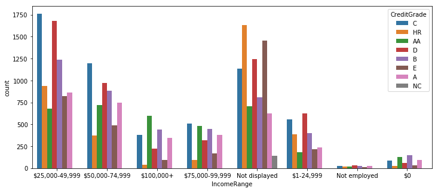

```python
plt.figure(figsize = (12, 5))
order_income = df['IncomeRange'].value_counts().index
sns.countplot(data = df, hue = 'CreditGrade', x = 'IncomeRange', order = order_income);
```

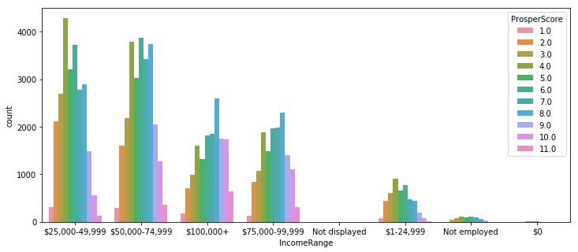

```python
plt.figure(figsize = (12, 5))
order_income = df['IncomeRange'].value_counts().index
sns.countplot(data = df, hue = 'ProsperScore', x = 'IncomeRange', order = order_income);
```

**According to the two charts above, we can say that the more income leads to better grade, but the reason why we don't see the better grades more often, may be depends on the users. Maybe the people with higher income won't need loan in most cases!**

> Walking around the columns of the dataframe, **I am interested in which quarter most loans taken during the period**

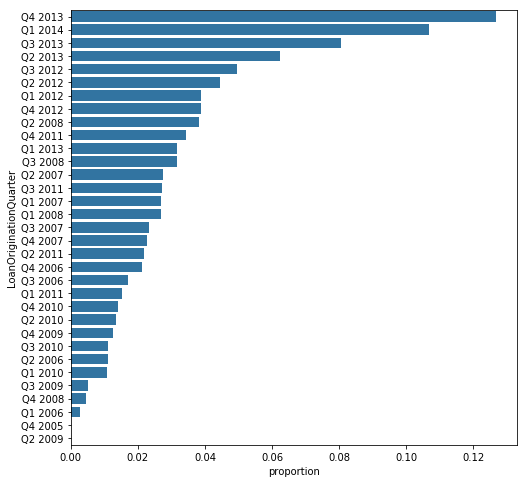

```python
plt.figure(figsize = (8, 8))
plot_proportions(df, 'LoanOriginationQuarter')
```

From the graph we can see, The second, the Third and the fourth quarters of 2013 are int beginning of the list. It looks like in this year many people used the platform. Do they take large amount or little? we don't know this but most people used prosper loans at this time!

> **What about looking at the relationship between, *Investor counts* and *Loan Amount***

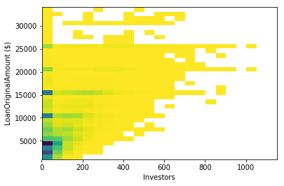

```python
# let's plot a heatmap for this time
x_bins = np.arange(1, df['Investors'].max(), 50)
y_bins = np.arange(1000, df['LoanOriginalAmount'].max(), 1000)

plt.hist2d(data = df, y = 'LoanOriginalAmount', x = 'Investors', cmap = 'viridis_r', cmin = 0.3, bins = [x_bins, y_bins]);
plt.xlabel('Investors')
plt.ylabel('LoanOriginalAmount ($)')
```

**We can see** more number investors investing for large amounts isn't so commom as small number investors investing for small amounts.

> **Let's look at the relationship of Credit Grade with *Loan Amount* and *Investors count***

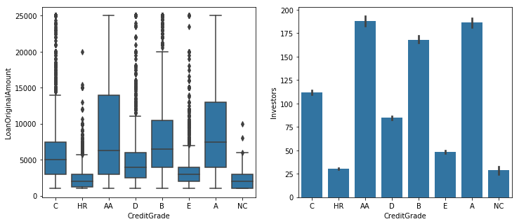

```python
# let's see both of them at once
plt.figure(figsize = (12, 5))
plt.subplot(1, 2, 1)
base_color = sns.color_palette()[0]
sns.boxplot(data = df, x = 'CreditGrade', y = 'LoanOriginalAmount', color = base_color);

plt.subplot(1, 2, 2)
sns.barplot(data = df, x = 'CreditGrade', y = 'Investors', color = base_color);
```

It looks like in most cases the people with better credit grades take loan in a range of 5000 and 15000 dollars. The other lower graded loans are often less than 8000 dollars but they have got many outliers. And more Investors also approves loans with higher grades.

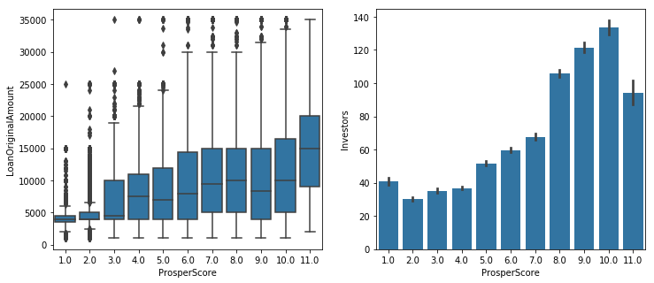

```python
# let's do the same with ProsperScore
plt.figure(figsize = (12, 5))
plt.subplot(1, 2, 1)
base_color = sns.color_palette()[0]
sns.boxplot(data = df, x = 'ProsperScore', y = 'LoanOriginalAmount', color = base_color);

plt.subplot(1, 2, 2)
sns.barplot(data = df, x = 'ProsperScore', y = 'Investors', color = base_color);
```

We have done the same thing with gradings after 2009 and got the same results.

> What about looking at the relationship between *Term* and *Loan Amount*

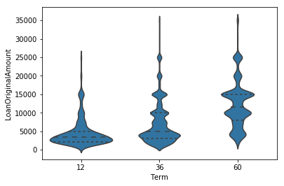

```python
# let's plot a violinplot for this
sns.violinplot(data = df, x = 'Term', y = 'LoanOriginalAmount', color = base_color, inner = 'quartile');
```

This plot can tell us much about on average loan amounts according to term. You can see the more people get loans less than 5000 dollars for a year. Larger amount of loans are taken for 3 or 5 years. Let's see how many people gets loan and how much amount.

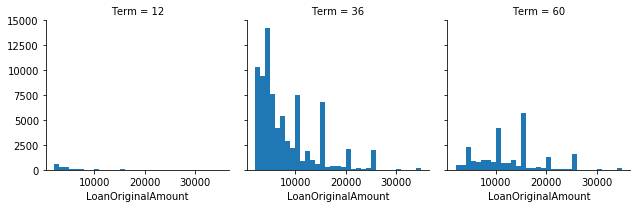

```python
# let's use faceting feature for this time
bin_list = np.arange(2000, 35000 + 1000, 1000)
g = sns.FacetGrid(data = df, col = 'Term')
g.map(plt.hist, 'LoanOriginalAmount', bins = bin_list);
```

Well the more people gets large amount of money for 3 years. **Maybe it depends on the Invester count and Icome range**.

> let's see what happens we add those features too.

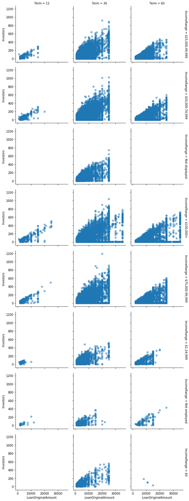

```python
# what about using scatterplot this time
g = sns.FacetGrid(data = df, col = 'Term', row = 'IncomeRange', margin_titles = True)
g.map(plt.scatter, 'LoanOriginalAmount', 'Investors', alpha = 0.5);
```

You can see both less income and high income borrowers teds to get more 3 year's loan than others but depending on income range their loan amount differs.

**There is a lot of colums so let's look at how the BorrowerAPR related to Loan Amount**

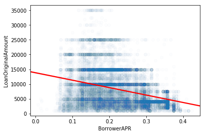

```python
# I think it is turn to regplot
sns.regplot(data = df.sample(20000), x = 'BorrowerAPR', y = 'LoanOriginalAmount', scatter_kws = {'alpha': 0.01},
           line_kws = {'color': 'red'});
```

From the graph we can find out that, If the BorrowerAPR inreases, Loan Amount tends to decrese.

> There is a lot of variables to take into account, so what about look through interactions of several of them with Loan Amount

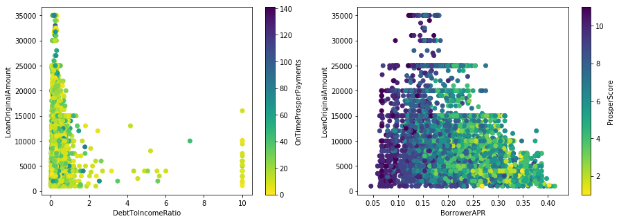

```python
# so let's do that I find interisting the columns below, if you have good ideas you can do with others
plt.figure(figsize = (15, 5))

plt.subplot(1, 2, 1)
plt.scatter(data = df, x = 'DebtToIncomeRatio', y = 'LoanOriginalAmount', c = 'OnTimeProsperPayments', cmap = 'viridis_r');
plt.colorbar(label = 'OnTimeProsperPayments')
plt.xlabel('DebtToIncomeRatio')
plt.ylabel('LoanOriginalAmount')

plt.subplot(1, 2, 2)
plt.scatter(data = df.sample(10000), x = 'BorrowerAPR', y = 'LoanOriginalAmount', c = 'ProsperScore', cmap = 'viridis_r');
plt.colorbar(label = 'ProsperScore')
plt.xlabel('BorrowerAPR')
plt.ylabel('LoanOriginalAmount')
```

> You can see from the first graph that If the dept to income ratio is lower there is more chance for you to get loan, your on time payments doesn't play that much role. According to the second graph, we can say the Lower APR and Higher Prosper score gives you more chance to take large amount of Loans.

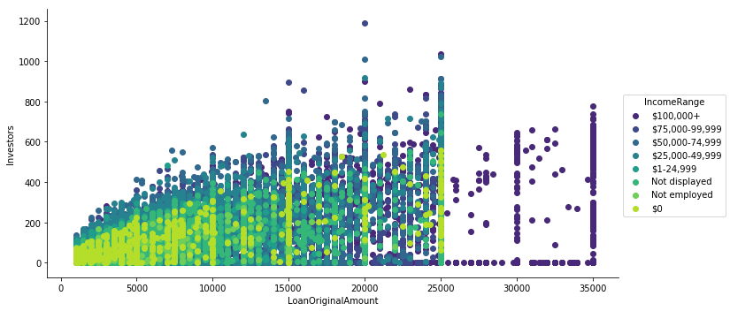

```python
g = sns.FacetGrid(data = df, hue = 'IncomeRange',
                  hue_order = ['$100,000+', '$75,000-99,999', '$50,000-74,999', '$25,000-49,999', '$1-24,999',
                              'Not displayed', 'Not employed', '$0'], size = 5, aspect = 2, palette = 'viridis')
g.map(plt.scatter, 'LoanOriginalAmount', 'Investors')
g.add_legend();
```

Yes, it tells us people with lower income can take at most 25000 dollars and on average 200 investors invest for them.

> **So far we have done a lot of investigations**, And I think it's time to make conclusions. Because my brain refuses to work any more like one of my friend says :-)

# Conclusion

> Ok, guys! Today we have done some insights to *Prosper Loan* data and try to answer the questions that we interested. I think we have done a good job! Do you remember the question we interested? If yes, help me to make conclusions. So, let's start.

According to the visualisations that we made, we can say following facts about the data.

- the most common loan amounts are 5k, 10k, and 15k dollars in the dataframe.
- the most common investment for each investor is between 30 and 100 dollars.
- the most common credit grades are moderate grades.
- your credit grade score depends on income range, the higher income leads to higher credit grade.
- in 2013 the prosper loans likely to be most common among users.
- the most common ivestment case we have seen is for lower amount of money and lower investors count.
- the people with higher credit score, get loan in a range between 5000 and 15000 dollars.
- more investors invest money to the loans with higher credit score.
- the most common loan term 3 years.
- it is likely that the people with middle income uses prosper loans
- lower APR leads to higher loan amount
- the loans with higher credit grade leads to lower APR

I think that's all for know. If you find further question to investigate, good luck with that!